# Lista de Exercícios 3: Transformada Z

> Felipe Andrade Garcia Tommaselli- 11800910

> Gianluca Capezzuto Sardinha - 11876900
- Slide Aula 3: https://marofe.github.io/controle-digital/2024/aula3.html

# Transformada Z

### Questão 1

Nessa atividade, o objetivo é usar o recurso de cálculo simbólico do Matlab para obter transformada Z de um sinal.

Para isso considere o seguinte exemplo: $f[n] = 10 − e^{−5nT}$

A transformada Z de $f[n]$ pode ser obtida usando o Matlab da seguinte forma: primeiramente, defina a equação literal no Matlab, para definir a variável $n$ e outras variáveis que existirem na equação como $T$, utilize o comando syms. Em seguida utilize o comando ztrans.

```python
import matplotlib.pyplot as plt
import numpy as np
import sympy as sp
import lcapy as lc

from lcapy import z, n
from lcapy.discretetime import n, z
from sympy import pprint, simplify
from utils import *
```

```python
# Define symbols for n and T
T = lc.symbols('T')
a = lc.symbols('a', real=True, positive=True)

# Define the sequence
example = 10 - lc.exp(-5 * n * T)
fa = 1 + n * (1/3)**n
fb = (1/2)**n + n * (1/5)**n
fc = lc.exp(a * n * T)
fd = n * T

# Compute the Z-transform of f[n]
Example_z = example.ZT()
Fa_z = fa.ZT()
Fb_z = fb.ZT()
Fc_z = fc.ZT()
Fd_z = fd.ZT()

# Simplify the Z-transform
Example_z = simplify(Example_z).evalf(1)
Fa_z = simplify(Fa_z).evalf(1)
Fb_z = simplify(Fb_z).evalf(1)
Fc_z = simplify(Fc_z).evalf(1)
Fd_z = simplify(Fd_z).evalf(1)
```

```python
print('Example Z-transform:')
pprint(Example_z)
```

```
Example Z-transform:
        5⋅T
     z⋅ℯ          1.0e+1
- ──────────── + ───────
     5⋅T               1
  z⋅ℯ    - 1.0   1.0 - ─
                       z
```

```python
print('_'*50)
print('Fa Z-transform:')
pprint(Fa_z)

print('_'*50)
print('Fb Z-transform:')
pprint(Fb_z)

print('_'*50)
print('Fc Z-transform:')
pprint(Fc_z)

print('_'*50)
print('Fd Z-transform:')
pprint(Fd_z)
```

```
__________________________________________________
Fa Z-transform:
           3.0e+31⋅z                  1
──────────────────────────────── + ───────
         2                               1
1.0e+32⋅z  - 7.0e+31⋅z + 1.0e+31   1.0 - ─
                                         z
__________________________________________________
Fb Z-transform:
   2.0⋅z        0.2⋅z
─────────── + ──────────
2.0⋅z - 1.0            2
              (z - 0.2)
__________________________________________________
Fc Z-transform:
   z
────────
     T⋅a
z - ℯ
__________________________________________________
Fd Z-transform:
   T⋅z
──────────
         2
(z - 1.0)
```

### Questão 2

Nessa atividade, o objetivo é usar o recurso de cálculo simbólico do MATLAB para obter a transformada Z Inversa. Para isso, considere o seguinte exemplo:

$$ F(z) = \frac{z}{z - \frac{1}{3}} $$

A transformada Z inversa de $F(z)$ pode ser obtida usando o MATLAB da seguinte forma: primeiramente defina a equação literal no MATLAB, para definir a variável $z$, e outras variáveis que existirem na equação, utilize o comando `syms`. Em seguida, utilize o comando `iztrans`. Após encontrar a transformada Z inversa, pode-se visualizar o sinal no tempo discreto usando o comando `subs`.

Seguindo a mesma lógica, encontre a transformada Z inversa dos seguintes sinais e mostre ao menos as 10 primeiras amostras usando `stem`.

1. $ F_a(z) = \frac{1}{z} $
2. $ F_b(z) = \frac{z + 2}{(z - \frac{1}{3})(z - \frac{1}{4})} $
3. $ F_c(z) = \frac{5z}{z - \frac{1}{2}} + \frac{2z}{(z - \frac{1}{9})^2} $
4. $ F_d(z) = \frac{5z(z - \cos(5))}{z^2 - 2 \cos(5)z + 1} $
5. $ F_e(z) = \frac{3z}{3z - 2} $

```python
# Define the sequence
F_a = 1 / z
F_b = (z + 2) / ((z - 1/3) * (z - 1/4))
F_c = (5 * z) / (z - 1/2) + (2 * z) / (z - 1/9)**2
F_d = (5 * z * (z - lc.cos(5))) / (z**2 - 2 * lc.cos(5) * z + 1)
F_e = (3 * z) / (3 * z - 2)

# Compute the inverse Z-transform of F[z]
F_a = F_a(n, causal=True)
F_b = F_b(n, causal=True)
F_c = F_c(n, causal=True)
F_d = F_d(n, causal=True)
F_e = F_e(n, causal=True)
```

```python
print('_'*50)
print("Inverse Z-transform of F_a[z]:\n")
pprint(F_a)

print('_'*50)
print("\nInverse Z-transform of F_b[z]:\n")
pprint(F_b)

print('_'*50)
print("\nInverse Z-transform of F_c[z]:\n")
print(F_c)

print('_'*50)
print("\nInverse Z-transform of F_d[z]:\n")
pprint(F_d)

print('_'*50)
print("\nInverse Z-transform of F_e[z]:\n")
pprint(F_e)
```

```
__________________________________________________
Inverse Z-transform of F_a[z]:

UnitImpulse(n - 1)
__________________________________________________

Inverse Z-transform of F_b[z]:

⎛
⎜                                                            ⎛1000000000000000
⎜                     -n   233333333333333330000000000000000⋅⎜────────────────
⎜  90000000000000000⋅4                                       ⎝ 333333333333333
⎜- ───────────────────── + ───────────────────────────────────────────────────
⎝     833333333333333                  2777777777777776388888888888889

  -n⎞
0⎞  ⎟
─⎟  ⎟
3⎠  ⎟               80000000000000000⋅UnitImpulse(n)
────⎟⋅UnitStep(n) + ────────────────────────────────
    ⎠                       3333333333333333
__________________________________________________

Inverse Z-transform of F_c[z]:

2*10**(16 - 16*n)*1111111111111111**(n - 1)*n*UnitStep(n) + 5*UnitStep(n)/2**n
__________________________________________________

Inverse Z-transform of F_d[z]:

5⋅cos(5⋅n)⋅UnitStep(n)
__________________________________________________

Inverse Z-transform of F_e[z]:

   -n
3/2  ⋅UnitStep(n)
```

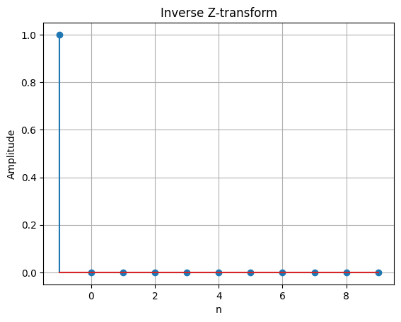

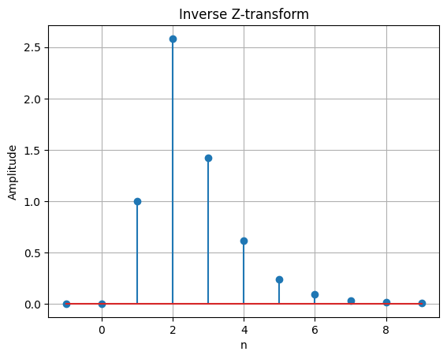

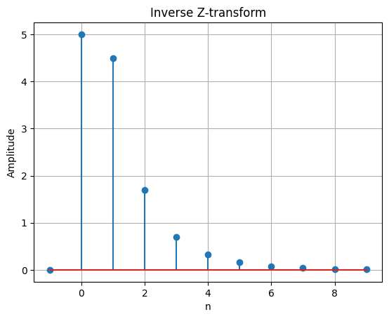

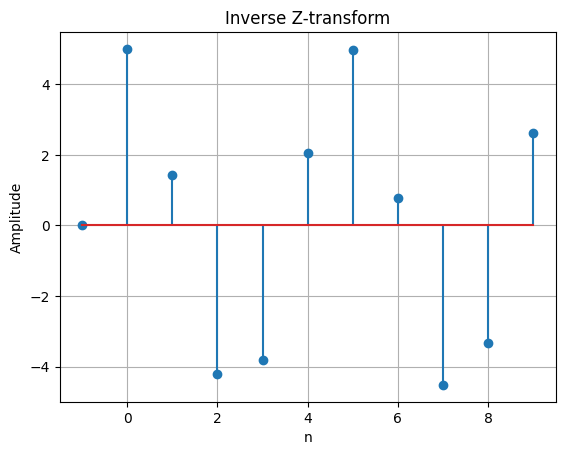

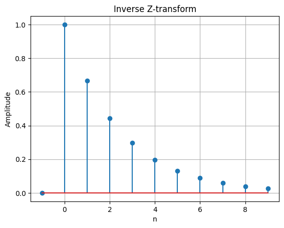

```python
LIM = 10
n_values = np.arange(-LIM, LIM)

for signal in [F_a, F_b, F_c, F_d, F_e]:
    signal_in = signal
    signal = PlotExpr(n_values, signal_in, LIM=LIM)

    plt.stem(n_values[len(n_values)//2 - 1:], signal[len(signal)//2 - 1:])
    plt.title(f'Inverse Z-transform')
    plt.xlabel('n')
    plt.ylabel('Amplitude')
    plt.grid(True)
    plt.show()
```

### Questão 3

Nessa atividade, o objetivo é usar o Matlab para obter as frações parciais de uma transformada Z na forma de função racional e em seguida obter a transformada Z inversa. Para isso, pode-se utilizar o comando `residuez` do Matlab conforme exemplo a seguir. Seja:

$$ X(z) = \frac{30(1 + 3z^{-1})}{30 - 16z^{-1} + 2z^{-2}} = \frac{A_1}{1 - p_1z^{-1}} + \frac{A_2}{1 - p_2z^{-1}} $$

Usando o seguinte código, obtém-se os coeficientes e polos da expansão em frações parciais de $X(z)$:

```
close all
clear all
clc
%%
format rational % configura exibição na forma de número racional
b = 30 * [1 3];
a = [30 -16 2];
[r, p] = residuez(b, a);
r % coeficientes
p % polos
```

Também pode-se obter a expansão em frações parciais usando o comando `residue`, porém, nesse caso, precisa considerar $X(z)$ na forma:

$$ X(z) = \frac{30z(z + 3)}{30z^2 - 16z + 2} $$

Portanto, primeiro deve-se considerar a expansão em frações parciais de $\frac{X(z)}{z}$:

$$ \frac{X(z)}{z} = \frac{30(z + 3)}{30z^2 - 16z + 2} = \frac{A_1}{z - p_1} + \frac{A_2}{z - p_2} $$

E após obter a expansão em frações parciais, basta multiplicar o resultado por $z$ para obter o resultado para $X(z)$:

$$ X(z) = \frac{A_1z}{z - p_1} + \frac{A_2z}{z - p_2} $$

Além do mais, tomando a Transformada Z inversa, pode-se obter o sinal $x[k]$ relacionado a $X(z)$ da mesma forma que na Atividade 2.

```
syms z % define variável simbólica
F = r(1) * z / (z - p(1)) + r(2) * z / (z - p(2)); % constrói transformada Z usando a expansão
f = iztrans(F); % calcula transformada Z inversa
t = 1:10; % define vetor de tempo discreto
fn = subs(f, 'n', t); % avalia f substituindo n por t
figure
stem(t, fn) % mostra resultado
```

**Atenção:** Caso tenha polos com multiplicidade, lembrar que precisa considerar a expansão na forma:

$$ \frac{1}{(z - p_j)^k} = \frac{A_{j1}}{(z - p_j)} + \frac{A_{j2}}{(z - p_j)^2} + \cdots + \frac{A_{jk}}{(z - p_j)^k} $$

ou

$$ \frac{1}{(1 - p_j z^{-1})^k} = \frac{A_{j1}}{(1 - p_j z^{-1})} + \frac{A_{j2}}{(1 - p_j z^{-1})^2} + \cdots + \frac{A_{jk}}{(1 - p_j z^{-1})^k}. $$

Seguindo a mesma lógica, encontre o sinal das seguintes transformadas Z e mostre as primeiras 10 amostras do sinal usando o comando `stem`:

1. $ F_a(z) = \frac{1 + 2z^{-1}}{(1 - 3z^{-1})(1 - 4z^{-1})} $
2. $ F_b(z) = \frac{(z^2 + z + 5)z}{z^3 - \frac{31}{36}z^2 + \frac{5}{24}z - \frac{1}{72}} $
3. $ F_c(z) = 5 \frac{(1 - \frac{1}{3}z^{-1})(1 - \frac{1}{5}z^{-1})}{(1 - \frac{1}{2}z^{-1})^2(1 - \frac{1}{9}z^{-1})} $
4. $ F_d(z) = \frac{z(z - 7)}{z^3 - \frac{25}{12}z^2 + \frac{35}{24}z - \frac{5}{12}z + \frac{1}{24}} $
5. $ F_e(z) = \frac{3z^2 + 10}{(10z - 4)^3} $

```python
z = sp.symbols('z')

# Define the transfer functions
F_a = (1 + 2/z) / ((1 - 3/z) * (1 - 4/z))
F_b = (z**2 + z + 5) * z / (z**3 - 31/36*z**2 + 5/24*z - 1/72)
F_c = 5 * ((1 - 1/3/z) * (1 - 1/5/z)) / ((1 - 1/2/z)**2 * (1 - 1/9/z))
F_d = z * (z - 7) / (z**3 - (25/12)*z**2 + (35/24)*z - (5/12) + (1/24))
F_e = (3*z**2 + 10) / ((10*z - 4)**3)

# Compute the partial fraction expansion of F[z]
F_a_partial = sp.apart(F_a, z)
F_b_partial = sp.apart(F_b, z)
F_c_partial = sp.apart(F_c, z)
F_d_partial = sp.apart(F_d, z)
F_e_partial = sp.apart(F_e, z)

print('_'*50)
print('F_a Partial Fraction Expansion:')
print(F_a_partial)

print('_'*50)
print('F_b Partial Fraction Expansion:')
print(F_b_partial)

print('_'*50)
print('F_c Partial Fraction Expansion:')
print(F_c_partial)

print('_'*50)
print('F_d Partial Fraction Expansion:')
print(F_d_partial)

print('_'*50)
print('F_e Partial Fraction Expansion:')
print(F_e_partial)
```

```
__________________________________________________
F_a Partial Fraction Expansion:
1 - 15/(z - 3) + 24/(z - 4)
__________________________________________________
F_b Partial Fraction Expansion:
1.0 + 10.5396825396825/(1.0*z - 0.111111111111111) - 38.25/(1.0*z - 0.25) + 29.5714285714286/(1.0*z - 0.5)
__________________________________________________
F_c Partial Fraction Expansion:
5.0 + 0.072562358276644/(1.0*z - 0.111111111111111) + 2.81632653061224/(1.0*z - 0.5) + 0.321428571428571/(1.0*z - 0.5)**2
__________________________________________________
F_d Partial Fraction Expansion:
19.9120879120879*(1.0*z - 0.357615894039735)/(0.923076923076923*z**2 - 1.0*z + 0.346153846153846) - 20.5714285714286/(z - 1)
__________________________________________________
F_e Partial Fraction Expansion:
3/(200*(5*z - 2)) + 3/(50*(5*z - 2)**2) + 131/(100*(5*z - 2)**3)
```

```python
from lcapy import z, n

F_a = 1 - 15/(z - 3) + 24/(z - 4)
F_b = 1.0 + 10.54/(z - 0.1111) - 38.25/(z - 0.25) + 29.57/(z - 0.5)
F_c = 5.0 + 0.07256/(z - 0.1111) + 2.82/(z - 0.5) + 0.3214/(z - 0.5)**2
F_d = 19.91*(z - 0.3576)/(0.9231*z**2 - z + 0.3462) - 20.57/(z - 1)
F_e = 3/(200*(5*z - 2)) + 3/(50*(5*z - 2)**2) + 131/(100*(5*z - 2)**3)

f_a = F_a.IZT(causal=True)
f_b = F_b.IZT(causal=True)
f_c = F_c.IZT(causal=True)
f_d = F_d.IZT(causal=True)
f_e = F_e.IZT(causal=True)

print('_'*50)
print('f_a[n]:')
print(f_a)

print('_'*50)
print('f_b[n]:')
print(f_b)

print('_'*50)
print('f_c[n]:')
print(f_c)

print('_'*50)
print('f_d[n]:')
print(f_d)

print('_'*50)
print('f_e[n]:')
print(f_e)
```

[output not shown]

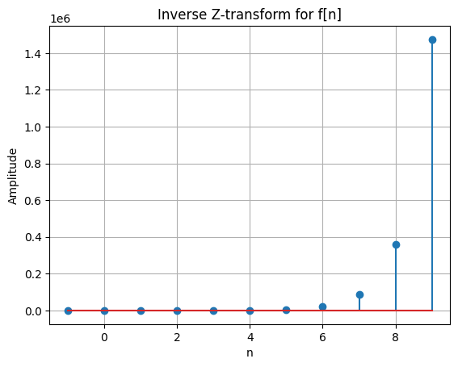

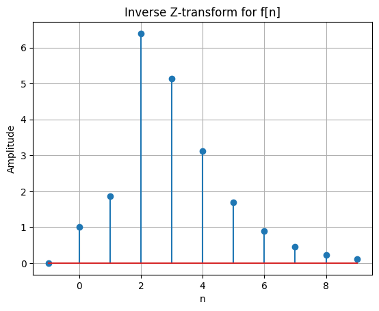

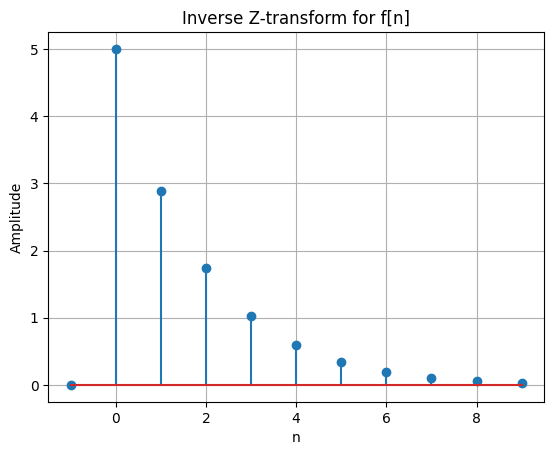

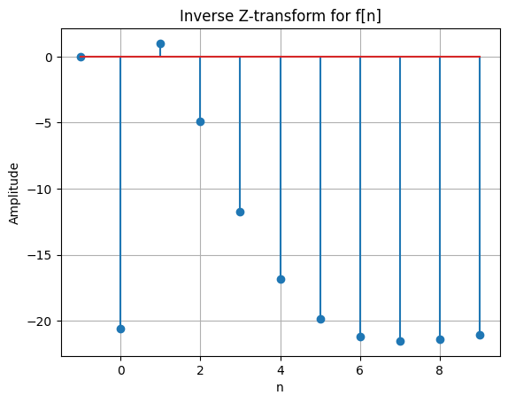

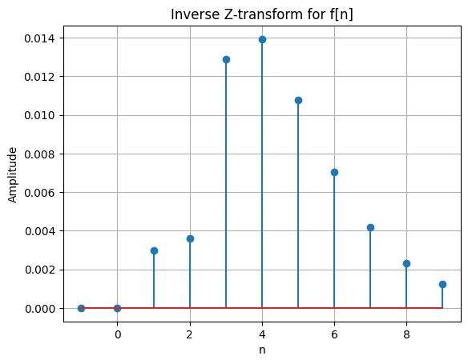

```python
LIM = 10
n_values = np.arange(-LIM, LIM)

for signal in [f_a, f_b, f_c, f_d, f_e]:
    signal_in = signal
    signal = PlotExpr(n_values, signal_in, LIM=LIM)

    plt.stem(n_values[len(n_values)//2 - 1:], signal[len(signal)//2 - 1:])
    plt.title(f'Inverse Z-transform for f[n]')
    plt.xlabel('n')
    plt.ylabel('Amplitude')
    plt.grid(True)
    plt.show()
```

## Questão 4

Usando a mesma lógica das atividades anteriores, encontre a resposta temporal do controle PID em tempo discreto a seguir. Para essa atividade, considere a transformada Z de um controlador tipo PID na forma:

$$ C(z) = \frac{U(z)}{E(z)} = K_P + \frac{T}{2} \frac{z + 1}{z - 1} K_I + \frac{z - 1}{T z} K_D $$

Considere também um erro em degrau $E(z) = \frac{z}{z-1}$. Obtenha a transformada Z inversa de $U(z)$ usando o Matlab e mostre o resultado das primeiras 10 amostras do sinal de controle usando o comando `stem` para $T = 1$, e:

1. $K_P = 1, K_I = 0$ e $K_D = 0$;
2. $K_P = 10, K_I = 0$ e $K_D = 0$;
3. $K_P = 1, K_I = 1$ e $K_D = 0$;
4. $K_P = 1, K_I = 10$ e $K_D = 0$;
5. $K_P = 1, K_I = 0$ e $K_D = 1$.

```
Case 1: K_P = 1, K_I = 0, K_D = 0
```

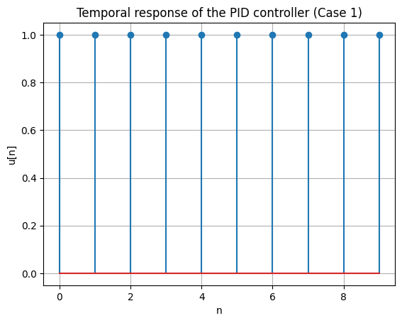

```
Case 2: K_P = 10, K_I = 0, K_D = 0
```

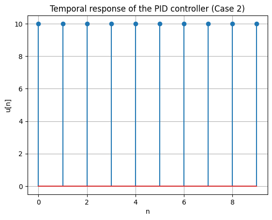

```
Case 3: K_P = 1, K_I = 1, K_D = 0
```

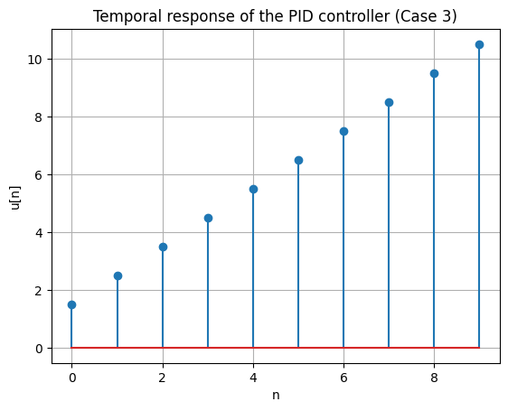

```
Case 4: K_P = 1, K_I = 10, K_D = 0
```

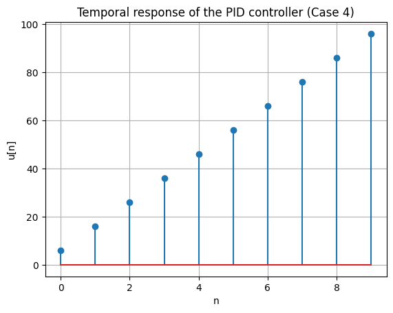

```
Case 5: K_P = 1, K_I = 0, K_D = 1
```

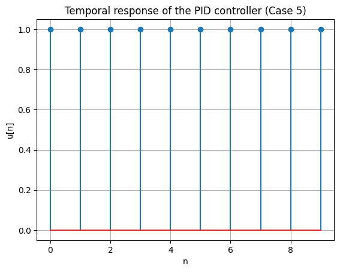

```python
def pid_response(K_P, K_I, K_D, E_z):
    """
    Function to compute the response of a PID controller to an error signal E(z)

    Parameters:
    K_P (float): Proportional gain
    K_I (float): Integral gain
    K_D (float): Derivative gain
    E_z (sympy expression): The error signal in the Z domain

    Returns:
    u_n (sympy expression): The response of the PID controller
    """
    # Define the transfer function of the PID controller
    C_z = K_P + (T / 2) * (z + 1) / (z - 1) * K_I + (z - 1) / (T * z) * K_D

    # Calculate the control signal U(z)
    U_z = C_z * E_z

    # Aplly the inverse Z-transform to get the control signal u[n]
    u_n = U_z.IZT(causal=True)

    return u_n

# Transfer function of the error signal
E_z = z / (z - 1)

# Define the values of n
n_values = np.arange(10)

print("Case 1: K_P = 1, K_I = 0, K_D = 0")
u_n_1 = pid_response(1, 0, 0, E_z)
signal_1 = PlotExpr(n_values, u_n_1, LIM=10)

plt.stem(n_values, signal_1)
plt.title('Temporal response of the PID controller (Case 1)')
plt.xlabel('n')
plt.ylabel('u[n]')
plt.grid(True)
plt.show()

print("Case 2: K_P = 10, K_I = 0, K_D = 0")
u_n_2 = pid_response(10, 0, 0, E_z)
signal_2 = PlotExpr(n_values, u_n_2, LIM=10)

plt.stem(n_values, signal_2)
plt.title('Temporal response of the PID controller (Case 2)')
plt.xlabel('n')
plt.ylabel('u[n]')
plt.grid(True)
plt.show()

print("Case 3: K_P = 1, K_I = 1, K_D = 0")
u_n_3 = pid_response(1, 1, 0, E_z)
signal_3 = PlotExpr(n_values, u_n_3, LIM=10)

plt.stem(n_values, signal_3)
plt.title('Temporal response of the PID controller (Case 3)')
plt.xlabel('n')
plt.ylabel('u[n]')
plt.grid(True)
plt.show()

print("Case 4: K_P = 1, K_I = 10, K_D = 0")
u_n_4 = pid_response(1, 10, 0, E_z)
signal_4 = PlotExpr(n_values, u_n_4, LIM=10)

plt.stem(n_values, signal_4)
plt.title('Temporal response of the PID controller (Case 4)')
plt.xlabel('n')
plt.ylabel('u[n]')
plt.grid(True)
plt.show()

print("Case 5: K_P = 1, K_I = 0, K_D = 1")
u_n_5 = pid_response(1, 0, 1, E_z)
signal_5 = PlotExpr(n_values, u_n_5, LIM=10)

plt.stem(n_values, signal_5)
plt.title('Temporal response of the PID controller (Case 5)')
plt.xlabel('n')
plt.ylabel('u[n]')
plt.grid(True)
plt.show()
```

### Questão 5

Considere um sistema de segunda ordem em tempo discreto dado por:

$$ G(z) = \frac{\omega_n^2 T^2 (z-1)^2}{4(z+1)^2 + T \omega_n \xi \frac{(z-1)}{(z+1)} + \omega_n^2} $$

1. Obtenha a transformada Z do sistema em malha fechada para $T = 1$, $\omega_n = 1$ e $\xi = 0.5$ usando o recurso de cálculo simbólico do Matlab. Lembre que a função de transferência em malha fechada (realimentação unitária) é dada por:

   $$ G_f(z) = \frac{Y(z)}{R(z)} = \frac{G(z)}{1 + G(z)} $$
2. Usando o Teorema do Valor Final, obtenha o valor de regime estacionário do sistema em malha fechada para uma referência em degrau deslocado em 1 amostra $\left(\hat{R}(z) = \frac{1}{z-1}\right)$ (dica: use o comando `subs` na transformada Z):

   $$ \lim_{n \to \infty} y[n] = \lim_{z \to 1} (z - 1)Y(z) $$
3. Mostre as 50 primeiras amostras do sinal de saída do sistema em malha fechada do exercício anterior usando o comando `stem`. A saída em regime estacionário coincide com o valor calculado pelo teorema do valor final?

Uma das possíveis causas é a **imprecisão numérica**. A complexidade da função de $Y(z)$, que envolve termos exponenciais elevados, raízes quadradas e partes imaginárias, pode ter gerado erros durante o processo de simplificação e avaliação numérica. Simplificações inadequadas podem ter eliminado termos que estabilizariam o sistema.

Outra possibilidade é um erro na **modelagem do sistema** ou na função de transferência $G(z)$. Caso os parâmetros do sistema, como $\omega_n$, $\xi$, ou $T$, estejam mal ajustados, isso pode ter causado um comportamento indesejado, resultando em uma resposta instável.

A **instabilidade do sistema** também é uma hipótese. Um sistema discreto é estável se todos os seus polos estão dentro do círculo unitário no plano Z. Se algum polo estiver fora desse círculo, a resposta do sistema pode crescer exponencialmente, como observado no gráfico.

Por fim, as **simplificações excessivas na transformada inversa de Z** podem ter contribuído para a discrepância. Termos importantes podem ter sido omitidos durante o processo de simplificação, levando a um resultado que não reflete o comportamento real do sistema.

```python
z = sp.symbols('z')

# System parameters
omega_n = 1
xi = 0.5
T = 1

# Transfer function of the plant G(z)
G_z = ((z - 1)**2) / (4*(z + 1)**2 + 0.5 * (z - 1) / (z + 1) + 1)

# Transfer function of the plant with feedback G_f(z)
G_f_z = G_z / (1 + G_z)

# Reference signal R(z)
R_z = 1 / (z - 1)

# Calculate the output Y(z)
Y_z = G_f_z * R_z

# Simplify the output Y(z)
Y_z_simplified = sp.simplify(Y_z)

print("Y(z):")
sp.pprint(Y_z_simplified)

# Compute the partial fraction expansion of Y(z)
Y_z_partial = sp.apart(Y_z_simplified, z)

print('_'*50)
print("Partial fraction expansion of Y(z):")
sp.pprint(Y_z_partial)

# Find the final value of Y(z) using the final value theorem
Y_final = sp.limit((z - 1) * Y_z, z, 1)
print('_'*50)
print(f"Final value of Y(z): {Y_final}")
```

[output not shown]

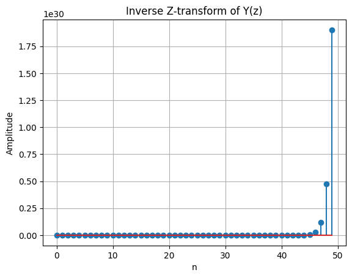

```python
Y_z_partial = 0.08 * (z - 1) * (z + 1) / (0.4 * z**3 + 0.88 * z**2 + 1.0 * z + 0.44)

# This is the inverse Z-transform of Y(z), but was taking a long time to compute, so I used a simplified version
# y_z = Y_z_partial.IZT(causal=True)
# y_z = Y_z_partial(n, causal=True)

LIM = 50
n_values = np.arange(LIM)
y_z = "UnitStep(n)*(-5*3**n + 6*4**n + 0.1*(0.9**n) - 0.2*(0.8**n))"

signal = PlotExpr(n_values, y_z, LIM=LIM)

plt.stem(n_values, signal)
plt.title('Inverse Z-transform of Y(z)')
plt.xlabel('n')
plt.ylabel('Amplitude')
plt.grid(True)
plt.show()
```